### Part I

#### Solution

Tuesday, November 19, 2013

**4.** Consider $Y_1$ and $Y_2$ to be two independent Binomial observations with sample sizes and probabilities ($n_1, p_1$) and ($n_2, p_2$), respectively. A typical example for which this setting is appropriate is a clinical trial where two treatments are being compared. Here $Y_i$ denotes the number of patients responding negatively to the treatment $i$ to which $n_i$ subjects were assigned and $p_i$ is the corresponding probabilities of negative response for $i=1,2$.

1. What is the likelihood function for ($p_1, p_2$)? What is the log-likelihood function for ($p_1, p_2$)? Determine the maximum likelihood estimator (MLE) of $p_1$ and $p_2$.  
   **Solution**  
   $\begin{align*} L(p_1, p_2) &= f(y_1, y_2 | p_1, p_2) \\ &= f(y_1|p_1) \cdot f(y_2|p_2) \\ &= `dbinom(x=y1, size=n1, prob=p1) * dbinom(x=y2, size=n2, prob=p2)` \\ \ell(p_1, p_2) &= `dbinom(x=y1, size=n1, prob=p1, log=TRUE) * dbinom(x=y2, size=n2, prob=p2, log=TRUE)` \end{align*}$ MLEs: $\hat{p}_1 = \frac{y_1}{n_1}, \ \ \ \hat{p}_2 = \frac{y_2}{n_2}$
2. Suppose $p_1 = p_2 = p$. What is the likelihood function for the common parameter $p$? What is the log-likelihood function for $p$? Determine the MLE of $p$.  
   **Solution**  
   $\begin{align*} L(p) &= f(y_1, y_2 | p) \\ &= f(y_1|p) \cdot f(y_2| p) \\ \ell(p) &= \log(f(y_1, p)) + \log(f(y_2|p)) \\ \end{align*}$ MLE: $\hat{p} = \frac{y_1 + y_2}{n_1 + n_2}$
3. Determine the Generalized Likelihood Ratio Test for $H_0: p_1 = p_2$ versus $H_1: p_1 \neq p_2$.  
   **Solution**  
   $\begin{gather} \Lambda = \frac{\max_{p} L(p)}{\max_{p_1, \ p_2} L(p_1, p_2)} = \frac{L(\hat{p})}{L(\hat{p}_1, \hat{p}_2)} \\ -2 \log \Lambda \sim \chi^2_{(1)} \\ -2 [\ell (\hat{p}) - \ell(\hat{p}_1, \hat{p}_2)] \\ 2 \ell(\hat{p}_1, \hat{p}_2) - \ell(\hat{p}) \end{gather}$

Alternatively, it is convenient to transform the parameters ($p_1, p_2$) to ($\theta_1, \theta_2$), where $\theta_1 = \log \bigg(\frac{p_1 (1 - p_2)}{p_2(1 - p_1)} \bigg)$ and $\theta_2 = \log \bigg(\frac{p_2}{1 - p_2} \bigg)$ and $\theta_1$ is referred to as the log-odds.

4. Using the Invariance Property of MLE’s determine the MLE of $\theta_1$.  
   **Solution**  
   $\begin{align*} \hat{\theta}_1 &= \log \left( \frac{\frac{y_1}{n_1} \left(1 - \frac{y_2}{n_2}\right)}{\frac{y_2}{n_2} \left(1 - \frac{y_1}{n_1}\right)}\right) \\ &= \log \left( \frac{y_1(n_2 - y_2)}{y_2(n_1 - y_1)} \right) \end{align*}$
5. Suggest how to use the parametric bootstrap to produce a confidence interval for $\theta_1$.  
   **Solution**  
   95% bootstrap confidence interval for $\theta_1$.  
   Data: $y_1 \sim f(y|p_1), \ y_2 \sim f(y|p_2)$ model.  
   Compute $\hat{\theta}_1$ with $n_1$ and $n_2$  
   Sample $(y_1^*, y_2^*)$ from $f(y|p_1) f(y|p_2)$ independently.  
   $y_1^* \sim Bin(n_1, \hat{p}_1)$  
   $y_2^* \sim Bin(n_2, \hat{p}_2)$  
   - $B=10,000$ times.  
   Compute $\hat{\theta}^*_{11}, \dots, \hat{\theta}_{1 \beta}$ from each bootstrap sample.  
   Histogram/density plot of the $\hat{\theta_1^*}$s is the bootstrap distribution for $\hat{\theta}_1$.  
   Approximate 95% bootstrap CI for $\theta_1$: $[\hat{\theta}^*_{1(2500)}, \hat{\theta}_{1(9750)}]$
6. If $y_1 = 40, n_1 = 100$, and $y_2 = 42, n_2 = 102$, then test $H_0: \theta_1 = 0$ versus $H_1: \theta_1 \neq 0$ using a 95% Bootstrap Confidence Interval produced by running the `logodds.R` program.  
   **Solution**

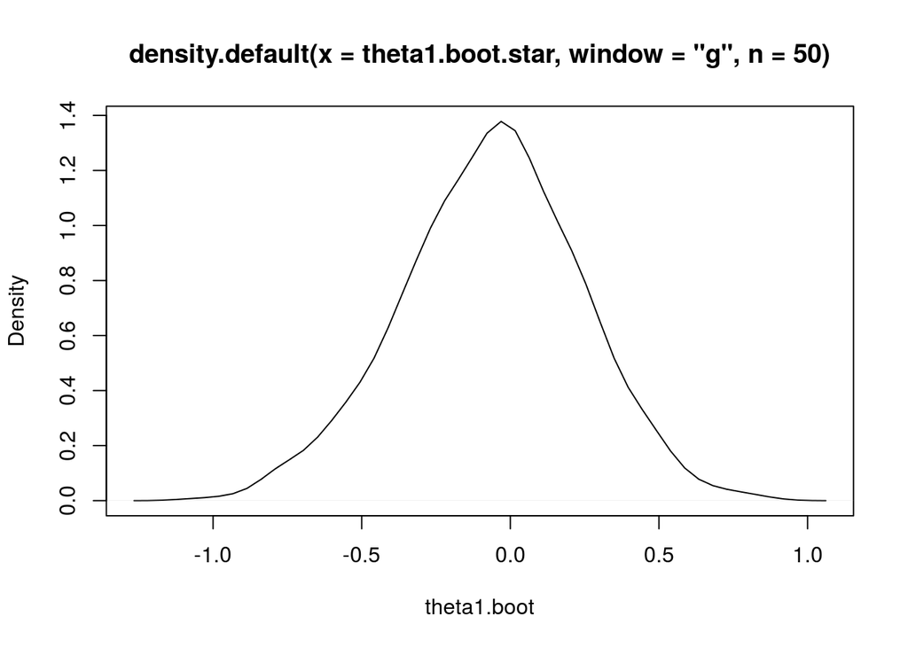

```r
# observed data

n1 = 100
n2 = 102

y1 = 40
y2 = 42

p1.hat = y1/n1
p2.hat = y2/n2

theta1.hat = log( (y1*(n2-y2))/(y2*(n1-y1)) )

# parametric bootstrap

B = 1000

theta1.boot.star = numeric(B)

for (i in 1:B){
    y1.boot = rbinom(1,n1,p1.hat)
    y2.boot = rbinom(1,n2,p2.hat)
    theta1.boot.star[i] = log( (y1.boot*(n2-y2.boot))/(y2.boot*(n1-y1.boot)) )
}

# bootstrap distribution for the log-odds

# modified code b/c original caused an error
# original was `theta1.boot`
plot(density(theta1.boot.star, n=50, window="g"), type="l", xlab="theta1.boot")
```

```r
theta1.boot.m = mean(theta1.boot.star)
theta1.boot.s = sd(theta1.boot.star)
theta1.boot.ci = quantile(theta1.boot.star,c(0.025,0.975))
theta1.boot.ci
```

```
##       2.5%      97.5%
## -0.6756705  0.4925755
```

```r
# asymptotic confidence interval for the log-odds

theta1.hat - 1.96*sqrt( 1/y1 + 1/(n1-y1) + 1/y2 + 1/(n2-y2) )
```

```
## [1] -0.6105374
```

```r
theta1.hat + 1.96*sqrt( 1/y1 + 1/(n1-y1) + 1/y2 + 1/(n2-y2) )
```

```
## [1] 0.5129571
```

```r
# Test H_0: \theta_1 = 0 versus H_1: \theta_1 != 0
```